# 06 KSM model tuning

# Goal

Construct a final two-stage model based on my previous work, computing:

$$E \left( \text{giving, donor | covariates} \right) = E \left(\text{giving | donor, covariates} \right) P \left(\text{donor | covariates} \right)$$

# Setup

```r
library(tidyverse)
library(reshape2)
library(gridExtra)
library(splines)
library(lubridate)
library(wranglR)
library(Boruta)
library(foreach)
library(doParallel)
library(mgcv)
# Functions adapted from previous analysis steps
source('code/functions.R')
# Visualization functions adapted fron previous analysis steps
source('code/functions_viz.R')
# Set number of available CPU cores
registerDoParallel(10)
```

```r
# Parameters
train_fy <- 2016
filepath <- 'data/2018-11-30 point-in-time data.xlsx'
sheetname <- 'Select point_in_time_model'

# Import data
source('code/generate-pit-data.R')

# Run data generation functions
modeling.data <- generate_pit_data(filepath, sheetname) %>%
  generate_additional_predictors()
```

```r
# Create cross-validation set
folds = 10
reps = 5

# Withhold 10% of data as test set
xv <- KFoldXVal(modeling.data, k = 2, prop = .1, seed = 6988432)
holdoutdat <- modeling.data[xv[[1]], ]
traindat <- modeling.data[xv[[2]], ]
remove(xv)
```

# Probability model tuning

I’ll perform a grid search to select reasonable spline parameters. To cut down on the number of combinations, similar variables will have the same number of spline dfs.

```r
# Splines grid search parameters
grid_params = list(
  giving = 2:3
  , dollars = 2:4
  , engagement = 2:3
  , recordyr = seq(3, 7, by = 2)
)
```

```r
print(grid_params)
```

```
$`giving`
[1] 2 3

$dollars
[1] 2 3 4

$engagement
[1] 2 3

$recordyr
[1] 3 5 7
```

This gives 36 combinations.

```r
# Store timings
glm_timestamps <- list()
# Store model errors
glm_errs <- list()
# Seed for reproducibility
set.seed(229786270)

# Outer loop (repetitions)
for (rep in 1:reps) {
  # Status report
  timestamp <- paste('+ Iteration', rep, 'beginning at:', Sys.time())
  print(timestamp)
  glm_timestamps <- c(glm_timestamps, timestamp)
  # Create cross-validation indices
  xv <- KFoldXVal(traindat, k = folds)
  # Middle loop (grid search)
  errs_out <- foreach(
    giving = grid_params$giving
    , .combine = c
    , .multicombine = TRUE
  ) %:% foreach(
    dollars = grid_params$dollars
    , .combine = c
    , .multicombine = TRUE
  ) %:% foreach(
    engagement = grid_params$engagement
    , .combine = c
    , .multicombine = TRUE
  ) %:% foreach(
    recordyr = grid_params$recordyr
    , .combine = c
    , .multicombine = TRUE
  ) %:% foreach(
  # Inner loop (parallel cross-validation)
    fold = 1:length(xv)
    , .combine = list
    , .multicombine = TRUE
    , .packages = c('dplyr', 'splines')
  ) %dopar% {
    # Fit temp model
    tmpmodel <- glm(
      rv.gave ~
      PROGRAM_GROUP +
      PREF_ADDR_TYPE_CODE +
      HOUSEHOLD_CONTINENT +
      BUS_IS_EMPLOYED +
      HAS_HOME_ADDR +
      HAS_HOME_PHONE +
      ns(YEARS_SINCE_FIRST_GIFT, df = giving) +
      ns(GIVING_FIRST_YEAR_CASH_AMT, df = giving) +
      ns(GIVING_MAX_PLEDGE_AMT, df = giving) +
      ns(GIVING_CASH_TOTAL, df = giving) +
      ns(GIVING_PLEDGE_TOTAL, df = giving) +
      ns(GIVING_CRU_TOTAL, df = giving) +
      ns(GIFTS_ALLOCS_SUPPORTED, df = giving) +
      ns(GIFTS_FYS_SUPPORTED, df = giving) +
      ns(GIFTS_CASH, df = giving) +
      ns(GIFTS_PLEDGES, df = giving) +
      ns(CASH_PFY1, df = dollars) +
      ns(CASH_PFY2, df = dollars) +
      ns(CASH_PFY3, df = dollars) +
      ns(CASH_PFY4, df = dollars) +
      ns(CASH_PFY5, df = dollars) +
      CRU_GIVING_SEGMENT +
      ns(EVALUATION_LOWER_BOUND, df = dollars) +
      ns(UOR_LOWER_BOUND, df = dollars) +
      ns(MONTHS_ASSIGNED, df = engagement) +
      ns(COMMITTEE_NU_DISTINCT, df = engagement) +
      ns(COMMITTEE_NU_YEARS, df = engagement) +
      ns(COMMITTEE_KSM_DISTINCT, df = engagement) +
      ns(EVENTS_PREV_3_FY, df = engagement) +
      ns(EVENTS_CFY, df = engagement) +
      ns(EVENTS_PFY1, df = engagement) +
      ns(ATHLETICS_TICKET_YEARS, df = engagement) +
      ns(YEARS_SINCE_ATHLETICS_TICKETS, df = engagement) +
      ns(RECORD_YR, df = recordyr) +
      ns(YEARS_SINCE_MAX_CASH_YR, df = giving) +
      GIVING_MAX_CASH_MO +
      KSM_PROSPECT +
      ns(VISITORS_5FY, df = engagement) +
      LOYAL_5_PCT_CASH +
      UPGRADE3_CASH +
      VELOCITY3_LIN_CASH +
      SPOUSE_ALUM
      , data = traindat[-xv[[fold]], ]
      , family = 'binomial'
    )
    # Prediction threshold
    theta1 <- sum(traindat$rv.gave[-xv[[fold]]] == 1) / nrow(traindat[-xv[[fold]], ])
    # Confusion matrix based on the withheld data
    tmpconfus <- conf_matrix(tmpmodel, newdata = traindat[xv[[fold]], ], rv = 'rv.gave', threshold = theta1)
    # Return results
    return(
      list(
        conf_matrix = tmpconfus$conf_matrix
        , conf_matrix_pct = tmpconfus$conf_matrix_pct
        , errors = data.frame(
          reps = rep
          , folds = fold
          , giving = giving
          , dollars = dollars
          , engagement = engagement
          , recordyr = recordyr
          , error = tmpconfus$error
          , precision = tmpconfus$precision
          , sensitivity = tmpconfus$sensitivity
          , F1_score = tmpconfus$F1_score
        )
      )
    )
  }
  # Write results to errors data frame
  glm_errs <- c(glm_errs, errs_out)
  # Status report
  timestamp <- paste(' -Iteration', rep, 'ending at:   ', Sys.time())
  print(timestamp)
  glm_timestamps <- c(glm_timestamps, timestamp)
}
```

```r
for(i in 1:length(glm_timestamps)) {print(glm_timestamps[[i]])}
```

```
[1] "+ Iteration 1 beginning at: 2019-01-07 22:21:07"
[1] " -Iteration 1 ending at:    2019-01-07 22:46:30"
[1] "+ Iteration 2 beginning at: 2019-01-07 22:46:30"
[1] " -Iteration 2 ending at:    2019-01-07 23:11:47"
[1] "+ Iteration 3 beginning at: 2019-01-07 23:11:47"
[1] " -Iteration 3 ending at:    2019-01-07 23:36:37"
[1] "+ Iteration 4 beginning at: 2019-01-07 23:36:37"
[1] " -Iteration 4 ending at:    2019-01-08 00:01:17"
[1] "+ Iteration 5 beginning at: 2019-01-08 00:01:17"
[1] " -Iteration 5 ending at:    2019-01-08 00:26:19"
```

```r
save(glm_errs, glm_timestamps, file = 'data/06_glm_xval.Rdata')
```

## Cross-validated errors

Examine the errors for each combination of spline dfs.

```r
glm_results <- foreach(i = ListExtract(glm_errs, 'errors'), .combine = rbind) %do% {i}
glm_results <- glm_results %>% mutate(
  reps = factor(reps)
  , folds = factor(folds)
  , giving = factor(giving)
  , dollars = factor(dollars)
  , engagement = factor(engagement)
  , recordyr = factor(recordyr)
  , splinedfs = paste0(giving, 'g ', dollars, 'd ', engagement, 'e ', recordyr, 'r')
)
```

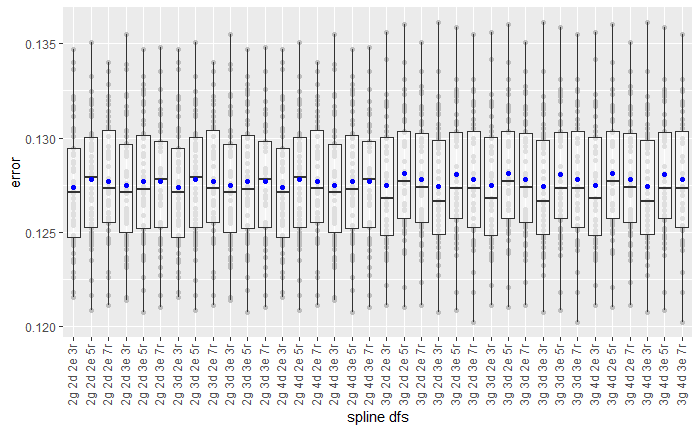

```r
glm_results %>%
  ggplot(aes(x = splinedfs, y = error)) +
  geom_point(color = 'gray') +
  geom_boxplot(alpha = .5) +
  stat_summary(fun.y = mean, color = 'blue', geom = 'point', show.legend = FALSE) +
  theme(axis.text.x = element_text(angle = 90, hjust = 1, vjust = .3)) +
  labs(x = 'spline dfs')
```

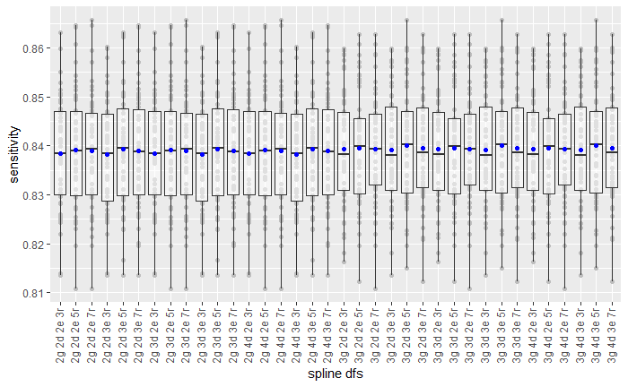

```r
glm_results %>%
  ggplot(aes(x = splinedfs, y = sensitivity)) +
  geom_point(color = 'gray') +
  geom_boxplot(alpha = .5) +
  stat_summary(fun.y = mean, color = 'blue', geom = 'point', show.legend = FALSE) +
  theme(axis.text.x = element_text(angle = 90, hjust = 1, vjust = .3)) +
  labs(x = 'spline dfs')
```

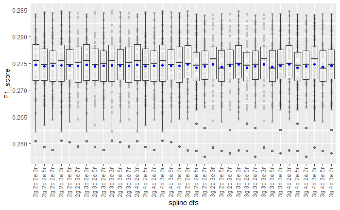

```r
glm_results %>%
  ggplot(aes(x = splinedfs, y = F1_score)) +
  geom_point(color = 'gray') +
  geom_boxplot(alpha = .5) +
  stat_summary(fun.y = mean, color = 'blue', geom = 'point', show.legend = FALSE) +
  theme(axis.text.x = element_text(angle = 90, hjust = 1, vjust = .3)) +
  labs(x = 'spline dfs')
```

Blue dots indicate means across all runs. There is honestly almost no difference between any of these models.

```r
glm_results %>%
  group_by(giving, dollars, engagement, recordyr) %>%
  summarise(mean_error = mean(error), mean_sensitivity = mean(sensitivity), mean_F1 = mean(F1_score)) %>%
  arrange(desc(mean_sensitivity))
```

| giving | dollars | engagement | recordyr | mean_error | mean_sensitivity | mean_F1 |
| --- | --- | --- | --- | --- | --- | --- |
| 3 | 2 | 3 | 5 | 0.1280540 | 0.8399780 | 0.5487190 |
| 3 | 3 | 3 | 5 | 0.1280540 | 0.8399780 | 0.5487190 |
| 3 | 4 | 3 | 5 | 0.1280540 | 0.8399780 | 0.5487190 |
| 3 | 2 | 3 | 7 | 0.1277964 | 0.8394871 | 0.5490739 |
| 3 | 3 | 3 | 7 | 0.1277964 | 0.8394871 | 0.5490739 |
| 3 | 4 | 3 | 7 | 0.1277964 | 0.8394871 | 0.5490739 |
| 3 | 2 | 2 | 5 | 0.1281013 | 0.8394162 | 0.5484634 |
| 3 | 3 | 2 | 5 | 0.1281013 | 0.8394162 | 0.5484634 |
| 3 | 4 | 2 | 5 | 0.1281013 | 0.8394162 | 0.5484634 |
| 2 | 2 | 3 | 5 | 0.1277018 | 0.8393873 | 0.5492323 |

[output cut: 26 more lines]

The 3-2-3-5 model appears to be reasonable.

```r
giving <- 3
dollars <- 2
engagement <- 3
recordyr <- 5
glm_trained <- glm(
  rv.gave ~
  PROGRAM_GROUP +
  PREF_ADDR_TYPE_CODE +
  HOUSEHOLD_CONTINENT +
  BUS_IS_EMPLOYED +
  HAS_HOME_ADDR +
  HAS_HOME_PHONE +
  ns(YEARS_SINCE_FIRST_GIFT, df = giving) +
  ns(GIVING_FIRST_YEAR_CASH_AMT, df = giving) +
  ns(GIVING_MAX_PLEDGE_AMT, df = giving) +
  ns(GIVING_CASH_TOTAL, df = giving) +
  ns(GIVING_PLEDGE_TOTAL, df = giving) +
  ns(GIVING_CRU_TOTAL, df = giving) +
  ns(GIFTS_ALLOCS_SUPPORTED, df = giving) +
  ns(GIFTS_FYS_SUPPORTED, df = giving) +
  ns(GIFTS_CASH, df = giving) +
  ns(GIFTS_PLEDGES, df = giving) +
  ns(CASH_PFY1, df = dollars) +
  ns(CASH_PFY2, df = dollars) +
  ns(CASH_PFY3, df = dollars) +
  ns(CASH_PFY4, df = dollars) +
  ns(CASH_PFY5, df = dollars) +
  CRU_GIVING_SEGMENT +
  ns(EVALUATION_LOWER_BOUND, df = dollars) +
  ns(UOR_LOWER_BOUND, df = dollars) +
  ns(MONTHS_ASSIGNED, df = engagement) +
  ns(COMMITTEE_NU_DISTINCT, df = engagement) +
  ns(COMMITTEE_NU_YEARS, df = engagement) +
  ns(COMMITTEE_KSM_DISTINCT, df = engagement) +
  ns(EVENTS_PREV_3_FY, df = engagement) +
  ns(EVENTS_CFY, df = engagement) +
  ns(EVENTS_PFY1, df = engagement) +
  ns(ATHLETICS_TICKET_YEARS, df = engagement) +
  ns(YEARS_SINCE_ATHLETICS_TICKETS, df = engagement) +
  ns(RECORD_YR, df = recordyr) +
  ns(YEARS_SINCE_MAX_CASH_YR, df = giving) +
  GIVING_MAX_CASH_MO +
  KSM_PROSPECT +
  ns(VISITORS_5FY, df = engagement) +
  LOYAL_5_PCT_CASH +
  UPGRADE3_CASH +
  VELOCITY3_LIN_CASH +
  SPOUSE_ALUM
  , data = traindat
  , family = 'binomial'
)
```

```r
summary(glm_trained)
```

```
Call:
glm(formula = rv.gave ~ PROGRAM_GROUP + PREF_ADDR_TYPE_CODE +
    HOUSEHOLD_CONTINENT + BUS_IS_EMPLOYED + HAS_HOME_ADDR + HAS_HOME_PHONE +
    ns(YEARS_SINCE_FIRST_GIFT, df = giving) + ns(GIVING_FIRST_YEAR_CASH_AMT,
    df = giving) + ns(GIVING_MAX_PLEDGE_AMT, df = giving) + ns(GIVING_CASH_TOTAL,
    df = giving) + ns(GIVING_PLEDGE_TOTAL, df = giving) + ns(GIVING_CRU_TOTAL,
    df = giving) + ns(GIFTS_ALLOCS_SUPPORTED, df = giving) +
    ns(GIFTS_FYS_SUPPORTED, df = giving) + ns(GIFTS_CASH, df = giving) +
    ns(GIFTS_PLEDGES, df = giving) + ns(CASH_PFY1, df = dollars) +
    ns(CASH_PFY2, df = dollars) + ns(CASH_PFY3, df = dollars) +
    ns(CASH_PFY4, df = dollars) + ns(CASH_PFY5, df = dollars) +
    CRU_GIVING_SEGMENT + ns(EVALUATION_LOWER_BOUND, df = dollars) +
    ns(UOR_LOWER_BOUND, df = dollars) + ns(MONTHS_ASSIGNED, df = engagement) +
    ns(COMMITTEE_NU_DISTINCT, df = engagement) + ns(COMMITTEE_NU_YEARS,
    df = engagement) + ns(COMMITTEE_KSM_DISTINCT, df = engagement) +
    ns(EVENTS_PREV_3_FY, df = engagement) + ns(EVENTS_CFY, df = engagement) +
    ns(EVENTS_PFY1, df = engagement) + ns(ATHLETICS_TICKET_YEARS,
    df = engagement) + ns(YEARS_SINCE_ATHLETICS_TICKETS, df = engagement) +
    ns(RECORD_YR, df = recordyr) + ns(YEARS_SINCE_MAX_CASH_YR,
    df = giving) + GIVING_MAX_CASH_MO + KSM_PROSPECT + ns(VISITORS_5FY,
    df = engagement) + LOYAL_5_PCT_CASH + UPGRADE3_CASH + VELOCITY3_LIN_CASH +
    SPOUSE_ALUM, family = "binomial", data = traindat)

Deviance Residuals:
    Min       1Q   Median       3Q      Max
-2.8049  -0.2722  -0.1387  -0.0315   3.9227

Coefficients: (38 not defined because of singularities)
                                                      Estimate Std. Error z value Pr(>|z|)
(Intercept)                                          17.258547  10.595677   1.629 0.103349
PROGRAM_GROUPNONE                                    -1.335266   0.120668 -11.066  < 2e-16 ***
PROGRAM_GROUPEMP                                     -0.170337   0.059169  -2.879 0.003991 **
PROGRAM_GROUPEXECED                                  -2.906542   0.346445  -8.390  < 2e-16 ***
PROGRAM_GROUPNONGRD                                  -1.690713   0.562674  -3.005 0.002658 **
PROGRAM_GROUPPHD                                      0.068883   0.203755   0.338 0.735312
PROGRAM_GROUPTMP                                     -0.286628   0.050096  -5.722 1.06e-08 ***
PREF_ADDR_TYPE_CODEALT                               -0.468018   0.172253  -2.717 0.006587 **
PREF_ADDR_TYPE_CODEBUS                               -0.023853   0.073844  -0.323 0.746679
HOUSEHOLD_CONTINENT                                  -2.288451   0.157594 -14.521  < 2e-16 ***
HOUSEHOLD_CONTINENTAsia                              -0.238902   0.087293  -2.737 0.006204 **
```

[output cut: 109 more lines]

```
UPGRADE3_CASH0                                        0.087203   0.174237   0.500 0.616734
UPGRADE3_CASH1                                        0.003868   0.208673   0.019 0.985211
UPGRADE3_CASH2                                       -0.005578   0.226402  -0.025 0.980345
VELOCITY3_LIN_CASH                                    0.016727   0.028022   0.597 0.550566
SPOUSE_ALUMTRUE                                       0.377920   0.084594   4.467 7.92e-06 ***
---
Signif. codes:  0 ‘***’ 0.001 ‘**’ 0.01 ‘*’ 0.05 ‘.’ 0.1 ‘ ’ 1

(Dispersion parameter for binomial family taken to be 1)

    Null deviance: 46997  on 76095  degrees of freedom
Residual deviance: 23579  on 76009  degrees of freedom
AIC: 23753

Number of Fisher Scoring iterations: 10
```

Whoops, there’s collinearity. Let’s try a trimmed model.

```r
glm_trained_fewsplines <- glm(
  rv.gave ~
  PROGRAM_GROUP +
  PREF_ADDR_TYPE_CODE +
  HOUSEHOLD_CONTINENT +
  BUS_IS_EMPLOYED +
  HAS_HOME_ADDR +
  HAS_HOME_PHONE +
  ns(YEARS_SINCE_FIRST_GIFT, df = 1) +
  ns(GIVING_FIRST_YEAR_CASH_AMT, df = 1) +
  ns(GIVING_MAX_PLEDGE_AMT, df = 1) +
  ns(GIVING_CASH_TOTAL, df = 1) +
  ns(GIVING_PLEDGE_TOTAL, df = 1) +
  ns(GIVING_CRU_TOTAL, df = 1) +
  ns(GIFTS_ALLOCS_SUPPORTED, df = 1) +
  ns(GIFTS_FYS_SUPPORTED, df = 1) +
  ns(GIFTS_CASH, df = 1) +
  ns(GIFTS_PLEDGES, df = 1) +
  ns(CASH_PFY1, df = 1) +
  ns(CASH_PFY2, df = 1) +
  ns(CASH_PFY3, df = 1) +
  ns(CASH_PFY4, df = 1) +
  ns(CASH_PFY5, df = 1) +
  CRU_GIVING_SEGMENT +
  ns(EVALUATION_LOWER_BOUND, df = 1) +
  ns(UOR_LOWER_BOUND, df = 1) +
  ns(MONTHS_ASSIGNED, df = 1) +
  ns(COMMITTEE_NU_DISTINCT, df = 1) +
  ns(COMMITTEE_NU_YEARS, df = 1) +
  ns(COMMITTEE_KSM_DISTINCT, df = 1) +
  ns(EVENTS_PREV_3_FY, df = 1) +
  ns(EVENTS_CFY, df = 1) +
  ns(EVENTS_PFY1, df = 1) +
  ns(ATHLETICS_TICKET_YEARS, df = 1) +
  ns(YEARS_SINCE_ATHLETICS_TICKETS, df = 1) +
  ns(RECORD_YR, df = 5) +
  ns(YEARS_SINCE_MAX_CASH_YR, df = 3) +
  GIVING_MAX_CASH_MO +
  KSM_PROSPECT +
  ns(VISITORS_5FY, df = 1) +
  LOYAL_5_PCT_CASH +
  UPGRADE3_CASH +
  VELOCITY3_LIN_CASH +
  SPOUSE_ALUM
  , data = traindat
  , family = 'binomial'
)
```

```r
summary(glm_trained_fewsplines)
```

```
Call:
glm(formula = rv.gave ~ PROGRAM_GROUP + PREF_ADDR_TYPE_CODE +
    HOUSEHOLD_CONTINENT + BUS_IS_EMPLOYED + HAS_HOME_ADDR + HAS_HOME_PHONE +
    ns(YEARS_SINCE_FIRST_GIFT, df = 1) + ns(GIVING_FIRST_YEAR_CASH_AMT,
    df = 1) + ns(GIVING_MAX_PLEDGE_AMT, df = 1) + ns(GIVING_CASH_TOTAL,
    df = 1) + ns(GIVING_PLEDGE_TOTAL, df = 1) + ns(GIVING_CRU_TOTAL,
    df = 1) + ns(GIFTS_ALLOCS_SUPPORTED, df = 1) + ns(GIFTS_FYS_SUPPORTED,
    df = 1) + ns(GIFTS_CASH, df = 1) + ns(GIFTS_PLEDGES, df = 1) +
    ns(CASH_PFY1, df = 1) + ns(CASH_PFY2, df = 1) + ns(CASH_PFY3,
    df = 1) + ns(CASH_PFY4, df = 1) + ns(CASH_PFY5, df = 1) +
    CRU_GIVING_SEGMENT + ns(EVALUATION_LOWER_BOUND, df = 1) +
    ns(UOR_LOWER_BOUND, df = 1) + ns(MONTHS_ASSIGNED, df = 1) +
    ns(COMMITTEE_NU_DISTINCT, df = 1) + ns(COMMITTEE_NU_YEARS,
    df = 1) + ns(COMMITTEE_KSM_DISTINCT, df = 1) + ns(EVENTS_PREV_3_FY,
    df = 1) + ns(EVENTS_CFY, df = 1) + ns(EVENTS_PFY1, df = 1) +
    ns(ATHLETICS_TICKET_YEARS, df = 1) + ns(YEARS_SINCE_ATHLETICS_TICKETS,
    df = 1) + ns(RECORD_YR, df = 5) + ns(YEARS_SINCE_MAX_CASH_YR,
    df = 3) + GIVING_MAX_CASH_MO + KSM_PROSPECT + ns(VISITORS_5FY,
    df = 1) + LOYAL_5_PCT_CASH + UPGRADE3_CASH + VELOCITY3_LIN_CASH +
    SPOUSE_ALUM, family = "binomial", data = traindat)

Deviance Residuals:
    Min       1Q   Median       3Q      Max
-2.9922  -0.2700  -0.1377  -0.0318   3.9352

Coefficients:
                                           Estimate Std. Error z value Pr(>|z|)
(Intercept)                               -7.101529   1.256583  -5.651 1.59e-08 ***
PROGRAM_GROUPNONE                         -1.354074   0.118263 -11.450  < 2e-16 ***
PROGRAM_GROUPEMP                          -0.182286   0.058561  -3.113 0.001854 **
PROGRAM_GROUPEXECED                       -2.877748   0.345560  -8.328  < 2e-16 ***
PROGRAM_GROUPNONGRD                       -1.611556   0.526535  -3.061 0.002208 **
PROGRAM_GROUPPHD                           0.069523   0.203946   0.341 0.733187
PROGRAM_GROUPTMP                          -0.281242   0.049754  -5.653 1.58e-08 ***
PREF_ADDR_TYPE_CODEALT                    -0.507201   0.172104  -2.947 0.003208 **
PREF_ADDR_TYPE_CODEBUS                    -0.046857   0.073901  -0.634 0.526051
HOUSEHOLD_CONTINENT                       -2.332723   0.159110 -14.661  < 2e-16 ***
HOUSEHOLD_CONTINENTAsia                   -0.260552   0.087154  -2.990 0.002794 **
HOUSEHOLD_CONTINENTEurope                 -1.034425   0.126443  -8.181 2.82e-16 ***
HOUSEHOLD_CONTINENTOther                  -0.774194   0.165241  -4.685 2.80e-06 ***
```

[output cut: 60 more lines]

```
UPGRADE3_CASH0                             0.070496   0.174332   0.404 0.685934
UPGRADE3_CASH1                             0.002094   0.208297   0.010 0.991979
UPGRADE3_CASH2                            -0.029189   0.225886  -0.129 0.897184
VELOCITY3_LIN_CASH                         0.024677   0.028142   0.877 0.380547
SPOUSE_ALUMTRUE                            0.385261   0.084400   4.565 5.00e-06 ***
---
Signif. codes:  0 ‘***’ 0.001 ‘**’ 0.01 ‘*’ 0.05 ‘.’ 0.1 ‘ ’ 1

(Dispersion parameter for binomial family taken to be 1)

    Null deviance: 46997  on 76095  degrees of freedom
Residual deviance: 23664  on 76018  degrees of freedom
AIC: 23820

Number of Fisher Scoring iterations: 10
```

How does this compare to a generalized additive model with the corresponding degrees of freedom?

```r
gam_trained <- gam(
  rv.gave ~
  PROGRAM_GROUP +
  PREF_ADDR_TYPE_CODE +
  HOUSEHOLD_CONTINENT +
  BUS_IS_EMPLOYED +
  HAS_HOME_ADDR +
  HAS_HOME_PHONE +
  s(YEARS_SINCE_FIRST_GIFT, k = giving) +
  s(GIVING_FIRST_YEAR_CASH_AMT, k = giving) +
  s(GIVING_MAX_PLEDGE_AMT, k = giving) +
  s(GIVING_CASH_TOTAL, k = giving) +
  s(GIVING_PLEDGE_TOTAL, k = giving) +
  s(GIVING_CRU_TOTAL, k = giving) +
  s(GIFTS_ALLOCS_SUPPORTED, k = giving) +
  s(GIFTS_FYS_SUPPORTED, k = giving) +
  s(GIFTS_CASH, k = giving) +
  s(GIFTS_PLEDGES, k = giving) +
  s(CASH_PFY1, k = dollars) +
  s(CASH_PFY2, k = dollars) +
  s(CASH_PFY3, k = dollars) +
  s(CASH_PFY4, k = dollars) +
  s(CASH_PFY5, k = dollars) +
  CRU_GIVING_SEGMENT +
  s(EVALUATION_LOWER_BOUND, k = dollars) +
  s(UOR_LOWER_BOUND, k = dollars) +
  s(MONTHS_ASSIGNED, k = engagement) +
  s(COMMITTEE_NU_DISTINCT, k = engagement) +
  s(COMMITTEE_NU_YEARS, k = engagement) +
  s(COMMITTEE_KSM_DISTINCT, k = engagement) +
  s(EVENTS_PREV_3_FY, k = engagement) +
  s(EVENTS_CFY, k = engagement) +
  s(EVENTS_PFY1, k = engagement) +
  s(ATHLETICS_TICKET_YEARS, k = engagement) +
  s(YEARS_SINCE_ATHLETICS_TICKETS, k = engagement) +
  s(RECORD_YR, k = recordyr) +
  s(YEARS_SINCE_MAX_CASH_YR, k = giving) +
  GIVING_MAX_CASH_MO +
  KSM_PROSPECT +
  s(VISITORS_5FY, k = engagement) +
  LOYAL_5_PCT_CASH +
  UPGRADE3_CASH +
  VELOCITY3_LIN_CASH +
  SPOUSE_ALUM
  , data = traindat
  , family = 'binomial'
  , control = list(nthreads = 10)
)
```

```
basis dimension, k, increased to minimum possible
basis dimension, k, increased to minimum possible
basis dimension, k, increased to minimum possible
basis dimension, k, increased to minimum possible
basis dimension, k, increased to minimum possible
basis dimension, k, increased to minimum possible
basis dimension, k, increased to minimum possible
```

```r
summary(gam_trained)
```

```
Family: binomial
Link function: logit

Formula:
rv.gave ~ PROGRAM_GROUP + PREF_ADDR_TYPE_CODE + HOUSEHOLD_CONTINENT +
    BUS_IS_EMPLOYED + HAS_HOME_ADDR + HAS_HOME_PHONE + s(YEARS_SINCE_FIRST_GIFT,
    k = giving) + s(GIVING_FIRST_YEAR_CASH_AMT, k = giving) +
    s(GIVING_MAX_PLEDGE_AMT, k = giving) + s(GIVING_CASH_TOTAL,
    k = giving) + s(GIVING_PLEDGE_TOTAL, k = giving) + s(GIVING_CRU_TOTAL,
    k = giving) + s(GIFTS_ALLOCS_SUPPORTED, k = giving) + s(GIFTS_FYS_SUPPORTED,
    k = giving) + s(GIFTS_CASH, k = giving) + s(GIFTS_PLEDGES,
    k = giving) + s(CASH_PFY1, k = dollars) + s(CASH_PFY2, k = dollars) +
    s(CASH_PFY3, k = dollars) + s(CASH_PFY4, k = dollars) + s(CASH_PFY5,
    k = dollars) + CRU_GIVING_SEGMENT + s(EVALUATION_LOWER_BOUND,
    k = dollars) + s(UOR_LOWER_BOUND, k = dollars) + s(MONTHS_ASSIGNED,
    k = engagement) + s(COMMITTEE_NU_DISTINCT, k = engagement) +
    s(COMMITTEE_NU_YEARS, k = engagement) + s(COMMITTEE_KSM_DISTINCT,
    k = engagement) + s(EVENTS_PREV_3_FY, k = engagement) + s(EVENTS_CFY,
    k = engagement) + s(EVENTS_PFY1, k = engagement) + s(ATHLETICS_TICKET_YEARS,
    k = engagement) + s(YEARS_SINCE_ATHLETICS_TICKETS, k = engagement) +
    s(RECORD_YR, k = recordyr) + s(YEARS_SINCE_MAX_CASH_YR, k = giving) +
    GIVING_MAX_CASH_MO + KSM_PROSPECT + s(VISITORS_5FY, k = engagement) +
    LOYAL_5_PCT_CASH + UPGRADE3_CASH + VELOCITY3_LIN_CASH + SPOUSE_ALUM

Parametric coefficients:
                                Estimate Std. Error z value Pr(>|z|)
(Intercept)                    -3.376523   0.250991 -13.453  < 2e-16 ***
PROGRAM_GROUPNONE              -1.319273   0.118042 -11.176  < 2e-16 ***
PROGRAM_GROUPEMP               -0.185938   0.058708  -3.167  0.00154 **
PROGRAM_GROUPEXECED            -2.886873   0.346196  -8.339  < 2e-16 ***
PROGRAM_GROUPNONGRD            -1.629511   0.546015  -2.984  0.00284 **
PROGRAM_GROUPPHD                0.059466   0.203209   0.293  0.76980
PROGRAM_GROUPTMP               -0.295126   0.049942  -5.909 3.43e-09 ***
PREF_ADDR_TYPE_CODEALT         -0.472400   0.172726  -2.735  0.00624 **
PREF_ADDR_TYPE_CODEBUS         -0.035903   0.073960  -0.485  0.62737
HOUSEHOLD_CONTINENT            -2.316842   0.157891 -14.674  < 2e-16 ***
HOUSEHOLD_CONTINENTAsia        -0.252339   0.087262  -2.892  0.00383 **
HOUSEHOLD_CONTINENTEurope      -0.993403   0.126665  -7.843 4.41e-15 ***
HOUSEHOLD_CONTINENTOther       -0.754464   0.165750  -4.552 5.32e-06 ***
BUS_IS_EMPLOYEDTRUE             0.303886   0.060194   5.048 4.45e-07 ***
```

[output cut: 53 more lines]

```
s(COMMITTEE_NU_YEARS)            1.005  1.009   1.611 0.206545
s(COMMITTEE_KSM_DISTINCT)        1.008  1.017   4.276 0.038911 *
s(EVENTS_PREV_3_FY)              1.034  1.059   0.994 0.312992
s(EVENTS_CFY)                    1.007  1.013   3.275 0.072960 .
s(EVENTS_PFY1)                   1.655  1.873   7.682 0.053856 .
s(ATHLETICS_TICKET_YEARS)        1.007  1.013   0.023 0.880186
s(YEARS_SINCE_ATHLETICS_TICKETS) 1.013  1.027   0.851 0.369474
s(RECORD_YR)                     2.949  3.279  36.341 9.21e-08 ***
s(YEARS_SINCE_MAX_CASH_YR)       1.864  1.981  79.278 4.04e-15 ***
s(VISITORS_5FY)                  1.787  1.954   3.959 0.164194
---
Signif. codes:  0 ‘***’ 0.001 ‘**’ 0.01 ‘*’ 0.05 ‘.’ 0.1 ‘ ’ 1

R-sq.(adj) =  0.472   Deviance explained = 49.9%
UBRE = -0.68825  Scale est. = 1         n = 76096
```

## Comparison

Comparing the model stats on the holdout data:

```r
# Prediction threshold
theta1 <- sum(traindat$rv.gave) / nrow(traindat)
# Confusion matrix based on the withheld data
glm_stats <- conf_matrix(glm_trained, newdata = holdoutdat, rv = 'rv.gave', threshold = theta1)
```

```
prediction from a rank-deficient fit may be misleading
```

```r
glm_stats5 <- conf_matrix(glm_trained, newdata = holdoutdat, rv = 'rv.gave', threshold = .5)
```

```
prediction from a rank-deficient fit may be misleading
```

```r
glm_fs_stats <- conf_matrix(glm_trained_fewsplines, newdata = holdoutdat, rv = 'rv.gave', threshold = theta1)
glm_fs_stats5 <- conf_matrix(glm_trained_fewsplines, newdata = holdoutdat, rv = 'rv.gave', threshold = .5)
gam_stats <- conf_matrix(gam_trained, newdata = holdoutdat, rv = 'rv.gave', threshold = theta1)
gam_stats5 <- conf_matrix(gam_trained, newdata = holdoutdat, rv = 'rv.gave', threshold = .5)
# Output
data.frame(
  model = c('glm', 'glm .5', 'glm fs', 'glm fs .5', 'gam', 'gam .5')
  , error = c(
    glm_stats$error, glm_stats5$error
    , glm_fs_stats$error, glm_fs_stats5$error
    , gam_stats$error, gam_stats5$error
  )
  , sensitivity = c(
    glm_stats$sensitivity, glm_stats5$sensitivity
    , glm_fs_stats$sensitivity, glm_fs_stats5$sensitivity
    , gam_stats$sensitivity, gam_stats5$sensitivity
  )
  , F1 = c(
    glm_stats$F1_score, glm_stats5$F1_score
    , glm_fs_stats$F1_score, glm_fs_stats5$F1_score
    , gam_stats$F1_score, gam_stats5$F1_score
  )
)
```

| model | error | sensitivity | F1 |
| --- | --- | --- | --- |
| glm | 0.12488174 | 0.8471850 | 0.5448276 |
| glm .5 | 0.05629139 | 0.5348525 | 0.6263736 |
| glm fs | 0.12464522 | 0.8458445 | 0.5449050 |
| glm fs .5 | 0.05581835 | 0.5294906 | 0.6259905 |
| gam | 0.12287133 | 0.8445040 | 0.5480644 |
| gam .5 | 0.05510880 | 0.5415550 | 0.6342229 |

On the out-of-sample holdout data, the GAM performs slightly better, though again the difference is minuscule.

Finally, consider the calibration plots.

```r
glm_preds <- data.frame(
  class = (holdoutdat$rv.gave + 0) %>% unlist()
  , glm = predict(glm_trained, newdata = holdoutdat, type = 'response')
  , glm_fs = predict(glm_trained_fewsplines, newdata = holdoutdat, type = 'response')
  , gam = predict(gam_trained, newdata = holdoutdat, type = 'response') %>% as.numeric()
) %>% gather(
  'model', 'prediction', glm:gam
)
```

```
prediction from a rank-deficient fit may be misleading
```

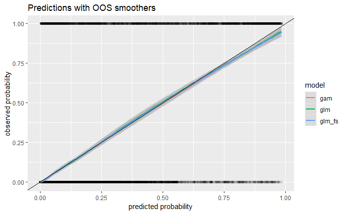

```r
glm_preds %>%
  ggplot(aes(x = prediction, y = class, group = model, color = model)) +
  geom_point(color = 'black', alpha  = .1) +
  geom_smooth(method = 'loess', alpha = .25) +
  geom_abline(slope = 1, intercept = 0) +
  labs(title = 'Predictions with OOS smoothers'
       , x = 'predicted probability'
       , y = 'observed probability')
```

No difference that the eye can see.

# Regression model tuning

The same grid search parameters will be used as in the previous step:

```r
remove(dollars, engagement, giving, recordyr)
print(grid_params)
```

```
$`giving`
[1] 2 3

$dollars
[1] 2 3 4

$engagement
[1] 2 3

$recordyr
[1] 3 5 7
```

```r
lm_traindat <- traindat %>%
  filter(rv.gave == TRUE)
```

Additionally, only the 7056 observed donors will be used to fit the regression model.

```r
# Store timings
lm_timestamps <- list()
# Store model errors
lm_errs <- list()
# Seed for reproducibility
set.seed(4822677)
# Outer loop (repetitions)
for (rep in 1:reps) {
  # Status report
  timestamp <- paste('+ Iteration', rep, 'beginning at:', Sys.time())
  print(timestamp)
  lm_timestamps <- c(lm_timestamps, timestamp)
  # Create cross-validation indices
  xv <- KFoldXVal(lm_traindat, k = folds)
  # Middle loop (grid search)
  errs_out <- foreach(
    giving = grid_params$giving
    , .combine = c
    , .multicombine = TRUE
  ) %:% foreach(
    dollars = grid_params$dollars
    , .combine = c
    , .multicombine = TRUE
  ) %:% foreach(
    engagement = grid_params$engagement
    , .combine = c
    , .multicombine = TRUE
  ) %:% foreach(
    recordyr = grid_params$recordyr
    , .combine = c
    , .multicombine = TRUE
  ) %:% foreach(
  # Inner loop (parallel cross-validation)
    fold = 1:length(xv)
    , .combine = list
    , .multicombine = TRUE
    , .packages = c('dplyr', 'splines')
  ) %dopar% {
    # Fit temp model
      tmpmodel <- lm(
        rv.amt ~
        COMMITTEE_KSM_LDR +
        ns(CRU_PFY1, df = dollars) +
        ns(CRU_PFY2, df = dollars) +
        ns(CRU_PFY3, df = dollars) +
        ns(CRU_PFY4, df = dollars) +
        ns(CRU_PFY5, df = dollars) +
        ns(EVALUATION_LOWER_BOUND, df = dollars) +
        GIFT_CLUB_NU_LDR_YRS +
        ns(GIFTS_ALLOCS_SUPPORTED, df = giving) +
        ns(GIFTS_OUTRIGHTS_PAYMENTS, df = giving) +
        ns(GIVING_CRU_TOTAL, df = giving) +
        ns(GIVING_MAX_CASH_YR, df = giving) +
        ns(GIVING_MAX_PLEDGE_AMT, df = giving) +
        ns(GIVING_MAX_PLEDGE_FY, df = giving) +
        HOUSEHOLD_CONTINENT +
        KSM_GOS_FLAG +
        LOYAL_5_PCT_ANY +
        ns(NGC_PFY1, df = dollars) +
        ns(NGC_PFY2, df = dollars) +
        ns(NGC_PFY3, df = dollars) +
        ns(NGC_PFY4, df = dollars) +
        ns(NGC_PFY5, df = dollars) +
        PREF_ADDR_TYPE_CODE +
        PROGRAM_GROUP +
        ns(RECORD_YR, df = recordyr) +
        ns(UOR_LOWER_BOUND, df = dollars) +
        UPGRADE3_CASH +
        ns(VELOCITY3_LIN_NGC, df = dollars) +
        ns(VISITS_5FY, df = engagement)
        # Train while withholding some data
        , data = lm_traindat[-xv[[fold]], ]
      )
      preds <- data.frame(
        prediction = predict(tmpmodel, newdata = lm_traindat[xv[[fold]], ], type = 'response')
        , actual = lm_traindat$rv.amt[xv[[fold]]]
      )
    # Return results
    return(
      list(
        params = data.frame(
          reps = rep
          , folds = fold
          , giving = giving
          , dollars = dollars
          , engagement = engagement
          , recordyr = recordyr
        )
        , adj.r.sq = summary(tmpmodel)$adj.r.sq
        , oos_preds = data.frame(
            rv.amt = lm_traindat[xv[[fold]], 'rv.amt']
            , preds = preds
        )
      )
    )
  }
  # Write results to errors data frame
  lm_errs <- c(lm_errs, errs_out)
  # Status report
  timestamp <- paste(' -Iteration', rep, 'ending at:   ', Sys.time())
  print(timestamp)
  lm_timestamps <- c(lm_timestamps, timestamp)
}
```

```
[1] "+ Iteration 1 beginning at: 2019-01-08 19:18:39"
[1] " -Iteration 1 ending at:    2019-01-08 19:18:51"
[1] "+ Iteration 2 beginning at: 2019-01-08 19:18:51"
[1] " -Iteration 2 ending at:    2019-01-08 19:19:02"
[1] "+ Iteration 3 beginning at: 2019-01-08 19:19:02"
[1] " -Iteration 3 ending at:    2019-01-08 19:19:13"
[1] "+ Iteration 4 beginning at: 2019-01-08 19:19:13"
[1] " -Iteration 4 ending at:    2019-01-08 19:19:25"
[1] "+ Iteration 5 beginning at: 2019-01-08 19:19:25"
[1] " -Iteration 5 ending at:    2019-01-08 19:19:37"
```

```r
save(lm_errs, lm_timestamps, file = 'data/06_lm_xval.Rdata')
```

## Cross-validated errors

Statistics for the different models.

```r
lm_results <- foreach(i = 1:length(lm_errs), .combine = rbind) %do% {
  data.frame(
    lm_errs[[i]]$params
    , adj.r.sq = lm_errs[[i]]$adj.r.sq
    , mse = calc_mse(y = lm_errs[[i]]$oos_preds$preds.actual, yhat = lm_errs[[i]]$oos_preds$preds.prediction)
  )
}
lm_results <- lm_results %>% mutate(
  reps = factor(reps)
  , folds = factor(folds)
  , giving = factor(giving)
  , dollars = factor(dollars)
  , engagement = factor(engagement)
  , recordyr = factor(recordyr)
  , splinedfs = paste0(giving, 'g ', dollars, 'd ', engagement, 'e ', recordyr, 'r')
)
```

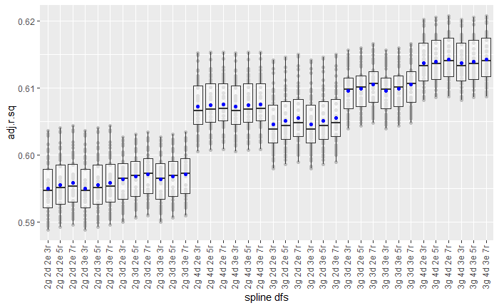

```r
lm_results %>%
  ggplot(aes(x = splinedfs, y = adj.r.sq)) +
  geom_point(color = 'gray') +
  geom_boxplot(alpha = .5) +
  stat_summary(fun.y = mean, color = 'blue', geom = 'point', show.legend = FALSE) +
  theme(axis.text.x = element_text(angle = 90, hjust = 1, vjust = .3)) +
  labs(x = 'spline dfs')
```

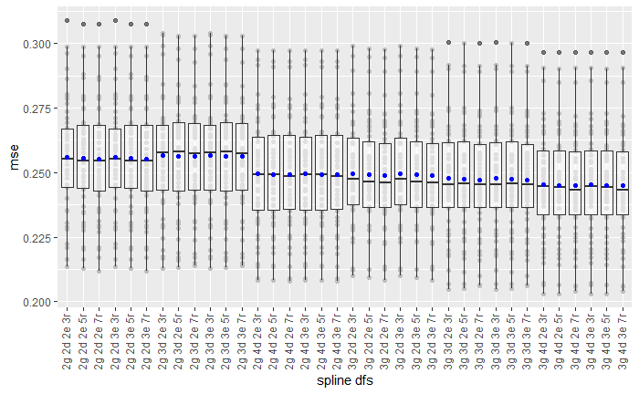

```r
lm_results %>%
  ggplot(aes(x = splinedfs, y = mse)) +
  geom_point(color = 'gray') +
  geom_boxplot(alpha = .5) +
  stat_summary(fun.y = mean, color = 'blue', geom = 'point', show.legend = FALSE) +
  theme(axis.text.x = element_text(angle = 90, hjust = 1, vjust = .3)) +
  labs(x = 'spline dfs')
```

```r
lm_results %>%
  group_by(giving, dollars, engagement, recordyr) %>%
  summarise(mean_mse = mean(mse), mean_adj.r.sq = mean(adj.r.sq)) %>%
  arrange(desc(mean_adj.r.sq))
```

| giving | dollars | engagement | recordyr | mean_mse | mean_adj.r.sq |
| --- | --- | --- | --- | --- | --- |
| 3 | 4 | 2 | 7 | 0.2449145 | 0.6142609 |
| 3 | 4 | 3 | 7 | 0.2449145 | 0.6142609 |
| 3 | 4 | 2 | 5 | 0.2450867 | 0.6139083 |
| 3 | 4 | 3 | 5 | 0.2450867 | 0.6139083 |
| 3 | 4 | 2 | 3 | 0.2451952 | 0.6136799 |
| 3 | 4 | 3 | 3 | 0.2451952 | 0.6136799 |
| 3 | 3 | 2 | 7 | 0.2472168 | 0.6104653 |
| 3 | 3 | 3 | 7 | 0.2472168 | 0.6104653 |
| 3 | 3 | 2 | 5 | 0.2475618 | 0.6098683 |
| 3 | 3 | 3 | 5 | 0.2475618 | 0.6098683 |

[output cut: 26 more lines]

The more df the merrier, apparently. 3, 4, 2, 7 is the smallest model maximizing $r^2_{\text{adj}}$.

```r
giving <- 3
dollars <- 4
engagement <- 2
recordyr <- 7
lm_trained <- lm(
  rv.amt ~
  COMMITTEE_KSM_LDR +
  ns(CRU_PFY1, df = dollars) +
  ns(CRU_PFY2, df = dollars) +
  ns(CRU_PFY3, df = dollars) +
  ns(CRU_PFY4, df = dollars) +
  ns(CRU_PFY5, df = dollars) +
  ns(EVALUATION_LOWER_BOUND, df = dollars) +
  GIFT_CLUB_NU_LDR_YRS +
  ns(GIFTS_ALLOCS_SUPPORTED, df = giving) +
  ns(GIFTS_OUTRIGHTS_PAYMENTS, df = giving) +
  ns(GIVING_CRU_TOTAL, df = giving) +
  ns(GIVING_MAX_CASH_YR, df = giving) +
  ns(GIVING_MAX_PLEDGE_AMT, df = giving) +
  ns(GIVING_MAX_PLEDGE_FY, df = giving) +
  HOUSEHOLD_CONTINENT +
  KSM_GOS_FLAG +
  LOYAL_5_PCT_ANY +
  ns(NGC_PFY1, df = dollars) +
  ns(NGC_PFY2, df = dollars) +
  ns(NGC_PFY3, df = dollars) +
  ns(NGC_PFY4, df = dollars) +
  ns(NGC_PFY5, df = dollars) +
  PREF_ADDR_TYPE_CODE +
  PROGRAM_GROUP +
  ns(RECORD_YR, df = recordyr) +
  ns(UOR_LOWER_BOUND, df = dollars) +
  UPGRADE3_CASH +
  ns(VELOCITY3_LIN_NGC, df = dollars) +
  ns(VISITS_5FY, df = engagement)
  , data = lm_traindat
)
```

```r
summary(lm_trained)
```

```
Call:
lm(formula = rv.amt ~ COMMITTEE_KSM_LDR + ns(CRU_PFY1, df = dollars) +
    ns(CRU_PFY2, df = dollars) + ns(CRU_PFY3, df = dollars) +
    ns(CRU_PFY4, df = dollars) + ns(CRU_PFY5, df = dollars) +
    ns(EVALUATION_LOWER_BOUND, df = dollars) + GIFT_CLUB_NU_LDR_YRS +
    ns(GIFTS_ALLOCS_SUPPORTED, df = giving) + ns(GIFTS_OUTRIGHTS_PAYMENTS,
    df = giving) + ns(GIVING_CRU_TOTAL, df = giving) + ns(GIVING_MAX_CASH_YR,
    df = giving) + ns(GIVING_MAX_PLEDGE_AMT, df = giving) + ns(GIVING_MAX_PLEDGE_FY,
    df = giving) + HOUSEHOLD_CONTINENT + KSM_GOS_FLAG + LOYAL_5_PCT_ANY +
    ns(NGC_PFY1, df = dollars) + ns(NGC_PFY2, df = dollars) +
    ns(NGC_PFY3, df = dollars) + ns(NGC_PFY4, df = dollars) +
    ns(NGC_PFY5, df = dollars) + PREF_ADDR_TYPE_CODE + PROGRAM_GROUP +
    ns(RECORD_YR, df = recordyr) + ns(UOR_LOWER_BOUND, df = dollars) +
    UPGRADE3_CASH + ns(VELOCITY3_LIN_NGC, df = dollars) + ns(VISITS_5FY,
    df = engagement), data = lm_traindat)

Residuals:
    Min      1Q  Median      3Q     Max
-3.6897 -0.2812 -0.0173  0.2217  3.7705

Coefficients: (27 not defined because of singularities)
                                            Estimate Std. Error t value Pr(>|t|)
(Intercept)                                12.190688   3.158261   3.860 0.000114 ***
COMMITTEE_KSM_LDR                           0.009644   0.014524   0.664 0.506722
ns(CRU_PFY1, df = dollars)1                -0.852196   0.459651  -1.854 0.063780 .
ns(CRU_PFY1, df = dollars)2                -0.539235   0.297136  -1.815 0.069601 .
ns(CRU_PFY1, df = dollars)3                -2.582926   1.238532  -2.085 0.037062 *
ns(CRU_PFY1, df = dollars)4                       NA         NA      NA       NA
ns(CRU_PFY2, df = dollars)1                -1.061993   0.232413  -4.569 4.97e-06 ***
ns(CRU_PFY2, df = dollars)2                -0.727779   0.154607  -4.707 2.56e-06 ***
ns(CRU_PFY2, df = dollars)3                       NA         NA      NA       NA
ns(CRU_PFY2, df = dollars)4                       NA         NA      NA       NA
ns(CRU_PFY3, df = dollars)1                -0.324302   0.212374  -1.527 0.126798
ns(CRU_PFY3, df = dollars)2                -0.371246   0.143997  -2.578 0.009953 **
ns(CRU_PFY3, df = dollars)3                       NA         NA      NA       NA
ns(CRU_PFY3, df = dollars)4                       NA         NA      NA       NA
ns(CRU_PFY4, df = dollars)1                 0.223311   0.206587   1.081 0.279755
ns(CRU_PFY4, df = dollars)2                -0.062872   0.135599  -0.464 0.642905
ns(CRU_PFY4, df = dollars)3                       NA         NA      NA       NA
ns(CRU_PFY4, df = dollars)4                       NA         NA      NA       NA
```

[output cut: 73 more lines]

```
UPGRADE3_CASH0                              0.099542   0.045742   2.176 0.029577 *
UPGRADE3_CASH1                              0.113065   0.052031   2.173 0.029812 *
UPGRADE3_CASH2                              0.176924   0.056452   3.134 0.001731 **
ns(VELOCITY3_LIN_NGC, df = dollars)1       -1.079994   0.197580  -5.466 4.76e-08 ***
ns(VELOCITY3_LIN_NGC, df = dollars)2       -0.582260   0.135086  -4.310 1.65e-05 ***
ns(VELOCITY3_LIN_NGC, df = dollars)3       -2.136689   0.439389  -4.863 1.18e-06 ***
ns(VELOCITY3_LIN_NGC, df = dollars)4       -0.265035   0.307470  -0.862 0.388724
ns(VISITS_5FY, df = engagement)1           -7.419183   1.629448  -4.553 5.37e-06 ***
ns(VISITS_5FY, df = engagement)2                  NA         NA      NA       NA
---
Signif. codes:  0 ‘***’ 0.001 ‘**’ 0.01 ‘*’ 0.05 ‘.’ 0.1 ‘ ’ 1

Residual standard error: 0.489 on 6983 degrees of freedom
Multiple R-squared:  0.6176,    Adjusted R-squared:  0.6136
F-statistic: 156.6 on 72 and 6983 DF,  p-value: < 2.2e-16
```

However, there are lots of collinearity issues….

```r
lm_trained_fewsplines <- lm(
  rv.amt ~
  COMMITTEE_KSM_LDR +
  ns(CRU_PFY1, df = 2) +
  ns(CRU_PFY2, df = 1) +
  ns(CRU_PFY3, df = 1) +
  ns(CRU_PFY4, df = 1) +
  ns(CRU_PFY5, df = 1) +
  ns(EVALUATION_LOWER_BOUND, df = 1) +
  GIFT_CLUB_NU_LDR_YRS +
  ns(GIFTS_ALLOCS_SUPPORTED, df = 1) +
  ns(GIFTS_OUTRIGHTS_PAYMENTS, df = 1) +
  ns(GIVING_CRU_TOTAL, df = 1) +
  ns(GIVING_MAX_CASH_YR, df = 1) +
  ns(GIVING_MAX_PLEDGE_AMT, df = 1) +
  ns(GIVING_MAX_PLEDGE_FY, df = 1) +
  HOUSEHOLD_CONTINENT +
  KSM_GOS_FLAG +
  LOYAL_5_PCT_ANY +
  ns(NGC_PFY1, df = 2) +
  ns(NGC_PFY2, df = 1) +
  ns(NGC_PFY3, df = 1) +
  ns(NGC_PFY4, df = 1) +
  ns(NGC_PFY5, df = 1) +
  PREF_ADDR_TYPE_CODE +
  PROGRAM_GROUP +
  ns(RECORD_YR, df = 5) +
  ns(UOR_LOWER_BOUND, df = 1) +
  UPGRADE3_CASH +
  ns(VELOCITY3_LIN_NGC, df = 7) +
  ns(VISITS_5FY, df = 1)
  , data = lm_traindat
)
```

```r
summary(lm_trained_fewsplines)
```

```
Call:
lm(formula = rv.amt ~ COMMITTEE_KSM_LDR + ns(CRU_PFY1, df = 2) +
    ns(CRU_PFY2, df = 1) + ns(CRU_PFY3, df = 1) + ns(CRU_PFY4,
    df = 1) + ns(CRU_PFY5, df = 1) + ns(EVALUATION_LOWER_BOUND,
    df = 1) + GIFT_CLUB_NU_LDR_YRS + ns(GIFTS_ALLOCS_SUPPORTED,
    df = 1) + ns(GIFTS_OUTRIGHTS_PAYMENTS, df = 1) + ns(GIVING_CRU_TOTAL,
    df = 1) + ns(GIVING_MAX_CASH_YR, df = 1) + ns(GIVING_MAX_PLEDGE_AMT,
    df = 1) + ns(GIVING_MAX_PLEDGE_FY, df = 1) + HOUSEHOLD_CONTINENT +
    KSM_GOS_FLAG + LOYAL_5_PCT_ANY + ns(NGC_PFY1, df = 2) + ns(NGC_PFY2,
    df = 1) + ns(NGC_PFY3, df = 1) + ns(NGC_PFY4, df = 1) + ns(NGC_PFY5,
    df = 1) + PREF_ADDR_TYPE_CODE + PROGRAM_GROUP + ns(RECORD_YR,
    df = 5) + ns(UOR_LOWER_BOUND, df = 1) + UPGRADE3_CASH + ns(VELOCITY3_LIN_NGC,
    df = 7) + ns(VISITS_5FY, df = 1), data = lm_traindat)

Residuals:
    Min      1Q  Median      3Q     Max
-3.6497 -0.2838 -0.0246  0.2344  3.8453

Coefficients:
                                      Estimate Std. Error t value Pr(>|t|)
(Intercept)                           1.342137   0.200791   6.684 2.50e-11 ***
COMMITTEE_KSM_LDR                     0.009129   0.014255   0.640 0.521936
ns(CRU_PFY1, df = 2)1                 0.247705   0.089666   2.763 0.005751 **
ns(CRU_PFY1, df = 2)2                 1.235312   0.173718   7.111 1.27e-12 ***
ns(CRU_PFY2, df = 1)                  0.020676   0.096572   0.214 0.830476
ns(CRU_PFY3, df = 1)                  0.079667   0.089047   0.895 0.370997
ns(CRU_PFY4, df = 1)                 -0.133781   0.073295  -1.825 0.068005 .
ns(CRU_PFY5, df = 1)                  0.042103   0.082319   0.511 0.609041
ns(EVALUATION_LOWER_BOUND, df = 1)    0.292373   0.034829   8.395  < 2e-16 ***
GIFT_CLUB_NU_LDR_YRS1+                0.206188   0.019093  10.799  < 2e-16 ***
ns(GIFTS_ALLOCS_SUPPORTED, df = 1)   -0.254905   0.121634  -2.096 0.036147 *
ns(GIFTS_OUTRIGHTS_PAYMENTS, df = 1) -0.885625   0.343738  -2.576 0.010002 *
ns(GIVING_CRU_TOTAL, df = 1)          0.618015   0.073389   8.421  < 2e-16 ***
ns(GIVING_MAX_CASH_YR, df = 1)        0.356717   0.081376   4.384 1.18e-05 ***
ns(GIVING_MAX_PLEDGE_AMT, df = 1)     0.950336   0.120251   7.903 3.14e-15 ***
ns(GIVING_MAX_PLEDGE_FY, df = 1)     -0.369905   0.045096  -8.203 2.77e-16 ***
HOUSEHOLD_CONTINENT                  -0.007994   0.063793  -0.125 0.900274
HOUSEHOLD_CONTINENTAsia               0.302329   0.035107   8.612  < 2e-16 ***
HOUSEHOLD_CONTINENTEurope            -0.017968   0.048933  -0.367 0.713491
HOUSEHOLD_CONTINENTOther              0.006453   0.070553   0.091 0.927124
```

[output cut: 25 more lines]

```
UPGRADE3_CASH2                        0.146876   0.057025   2.576 0.010026 *
ns(VELOCITY3_LIN_NGC, df = 7)1       -0.335598   0.147500  -2.275 0.022921 *
ns(VELOCITY3_LIN_NGC, df = 7)2        0.465314   0.171532   2.713 0.006690 **
ns(VELOCITY3_LIN_NGC, df = 7)3       -0.007732   0.165961  -0.047 0.962841
ns(VELOCITY3_LIN_NGC, df = 7)4        0.117053   0.162736   0.719 0.471993
ns(VELOCITY3_LIN_NGC, df = 7)5        0.272743   0.103848   2.626 0.008649 **
ns(VELOCITY3_LIN_NGC, df = 7)6        0.420053   0.337472   1.245 0.213282
ns(VELOCITY3_LIN_NGC, df = 7)7       -1.973372   0.307488  -6.418 1.47e-10 ***
ns(VISITS_5FY, df = 1)                0.930161   0.218267   4.262 2.06e-05 ***
---
Signif. codes:  0 ‘***’ 0.001 ‘**’ 0.01 ‘*’ 0.05 ‘.’ 0.1 ‘ ’ 1

Residual standard error: 0.4987 on 7002 degrees of freedom
Multiple R-squared:  0.6012,    Adjusted R-squared:  0.5981
F-statistic: 199.1 on 53 and 7002 DF,  p-value: < 2.2e-16
```

I’ll also fit a GAM with the same initial degrees of freedom as a point of comparison.

```r
gam_lm_trained <- gam(
  rv.amt ~
  COMMITTEE_KSM_LDR +
  s(CRU_PFY1, k = dollars) +
  s(CRU_PFY2, k = dollars) +
  s(CRU_PFY3, k = dollars) +
  s(CRU_PFY4, k = dollars) +
  s(CRU_PFY5, k = dollars) +
  s(EVALUATION_LOWER_BOUND, k = dollars) +
  GIFT_CLUB_NU_LDR_YRS +
  s(GIFTS_ALLOCS_SUPPORTED, k = giving) +
  s(GIFTS_OUTRIGHTS_PAYMENTS, k = giving) +
  s(GIVING_CRU_TOTAL, k = giving) +
  s(GIVING_MAX_CASH_YR, k = giving) +
  s(GIVING_MAX_PLEDGE_AMT, k = giving) +
  s(GIVING_MAX_PLEDGE_FY, k = giving) +
  HOUSEHOLD_CONTINENT +
  KSM_GOS_FLAG +
  LOYAL_5_PCT_ANY +
  s(NGC_PFY1, k = dollars) +
  s(NGC_PFY2, k = dollars) +
  s(NGC_PFY3, k = dollars) +
  s(NGC_PFY4, k = dollars) +
  s(NGC_PFY5, k = dollars) +
  PREF_ADDR_TYPE_CODE +
  PROGRAM_GROUP +
  s(RECORD_YR, k = recordyr) +
  s(UOR_LOWER_BOUND, k = dollars) +
  UPGRADE3_CASH +
  s(VELOCITY3_LIN_NGC, k = dollars) +
  s(VISITS_5FY, k = engagement)
  , data = lm_traindat
  , family = 'gaussian'
  , control = list(nthreads = 10)
)
```

```
basis dimension, k, increased to minimum possible
```

```r
summary(gam_lm_trained)
```

```
Family: gaussian
Link function: identity

Formula:
rv.amt ~ COMMITTEE_KSM_LDR + s(CRU_PFY1, k = dollars) + s(CRU_PFY2,
    k = dollars) + s(CRU_PFY3, k = dollars) + s(CRU_PFY4, k = dollars) +
    s(CRU_PFY5, k = dollars) + s(EVALUATION_LOWER_BOUND, k = dollars) +
    GIFT_CLUB_NU_LDR_YRS + s(GIFTS_ALLOCS_SUPPORTED, k = giving) +
    s(GIFTS_OUTRIGHTS_PAYMENTS, k = giving) + s(GIVING_CRU_TOTAL,
    k = giving) + s(GIVING_MAX_CASH_YR, k = giving) + s(GIVING_MAX_PLEDGE_AMT,
    k = giving) + s(GIVING_MAX_PLEDGE_FY, k = giving) + HOUSEHOLD_CONTINENT +
    KSM_GOS_FLAG + LOYAL_5_PCT_ANY + s(NGC_PFY1, k = dollars) +
    s(NGC_PFY2, k = dollars) + s(NGC_PFY3, k = dollars) + s(NGC_PFY4,
    k = dollars) + s(NGC_PFY5, k = dollars) + PREF_ADDR_TYPE_CODE +
    PROGRAM_GROUP + s(RECORD_YR, k = recordyr) + s(UOR_LOWER_BOUND,
    k = dollars) + UPGRADE3_CASH + s(VELOCITY3_LIN_NGC, k = dollars) +
    s(VISITS_5FY, k = engagement)

Parametric coefficients:
                            Estimate Std. Error t value Pr(>|t|)
(Intercept)                2.4302501  0.0486187  49.986  < 2e-16 ***
COMMITTEE_KSM_LDR          0.0022012  0.0146020   0.151 0.880179
GIFT_CLUB_NU_LDR_YRS1+     0.1635981  0.0200976   8.140 4.64e-16 ***
HOUSEHOLD_CONTINENT       -0.0331306  0.0635381  -0.521 0.602085
HOUSEHOLD_CONTINENTAsia    0.2861440  0.0348392   8.213 2.54e-16 ***
HOUSEHOLD_CONTINENTEurope -0.0491744  0.0484796  -1.014 0.310459
HOUSEHOLD_CONTINENTOther  -0.0252825  0.0698879  -0.362 0.717544
KSM_GOS_FLAGTRUE           0.2021911  0.0368503   5.487 4.24e-08 ***
LOYAL_5_PCT_ANY            0.0729756  0.1606786   0.454 0.649720
PREF_ADDR_TYPE_CODEALT     0.0798011  0.0650707   1.226 0.220099
PREF_ADDR_TYPE_CODEBUS     0.0975161  0.0270551   3.604 0.000315 ***
PROGRAM_GROUPNONE          0.1459548  0.0457151   3.193 0.001416 **
PROGRAM_GROUPEMP          -0.0001198  0.0211937  -0.006 0.995489
PROGRAM_GROUPEXECED       -0.3550450  0.1655037  -2.145 0.031968 *
PROGRAM_GROUPNONGRD       -0.1660252  0.2459267  -0.675 0.499634
PROGRAM_GROUPPHD          -0.0196553  0.0754522  -0.261 0.794485
PROGRAM_GROUPTMP          -0.0473425  0.0170276  -2.780 0.005445 **
UPGRADE3_CASH-1            0.0812776  0.0464482   1.750 0.080187 .
UPGRADE3_CASH0             0.1198418  0.0459785   2.606 0.009167 **
UPGRADE3_CASH1             0.0907958  0.0522013   1.739 0.082019 .
```

[output cut: 17 more lines]

```
s(GIVING_MAX_PLEDGE_FY)     1.133  1.247 39.169 1.11e-10 ***
s(NGC_PFY1)                 2.408  2.738  7.612 0.000102 ***
s(NGC_PFY2)                 2.106  2.462  2.114 0.100366
s(NGC_PFY3)                 2.801  2.959  4.473 0.002555 **
s(NGC_PFY4)                 2.580  2.848  1.497 0.164817
s(NGC_PFY5)                 3.000  3.000  8.574 1.12e-05 ***
s(RECORD_YR)                5.014  5.536 24.342  < 2e-16 ***
s(UOR_LOWER_BOUND)          2.191  2.480 11.534 1.45e-06 ***
s(VELOCITY3_LIN_NGC)        3.000  3.000 21.416 8.34e-14 ***
s(VISITS_5FY)               1.000  1.000  6.656 0.009903 **
---
Signif. codes:  0 ‘***’ 0.001 ‘**’ 0.01 ‘*’ 0.05 ‘.’ 0.1 ‘ ’ 1

R-sq.(adj) =  0.606   Deviance explained =   61%
GCV = 0.24604  Scale est. = 0.24363   n = 7056
```

## Comparison

Comparing the stats on the holdout set:

```r
data.frame(
  model = c('lm', 'lm_small', 'gam')
  , adj.r.sq = c(
    summary(lm_trained)$adj.r.sq
    , summary(lm_trained_fewsplines)$adj.r.sq
    , summary(gam_lm_trained)$r.sq
  )
  , insample_mse = c(
    calc_mse(y = lm_trained$model$rv.amt, yhat = lm_trained$fitted)
    , calc_mse(y = lm_trained_fewsplines$model$rv.amt, yhat = lm_trained_fewsplines$fitted)
    , calc_mse(y = gam_lm_trained$y, yhat = gam_lm_trained$fitted)
  )
  , outsample_mse = c(
    calc_mse(y = holdoutdat$rv.amt, yhat = predict(lm_trained, newdata = holdoutdat))
    , calc_mse(y = holdoutdat$rv.amt, yhat = predict(lm_trained_fewsplines, newdata = holdoutdat))
    , calc_mse(y = holdoutdat$rv.amt, yhat = predict(gam_lm_trained, newdata = holdoutdat))
  )
)
```

```
prediction from a rank-deficient fit may be misleading
```

| model | adj.r.sq | insample_mse | outsample_mse |
| --- | --- | --- | --- |
| lm | 0.6136301 | 0.2366075 | 4.718346 |
| lm_small | 0.5981447 | 0.2467601 | 4.450881 |
| gam | 0.6062771 | 0.2412412 | 4.463956 |

The model with collinearity is clearly overfit, while the other two models are essentially interchangeable. In general, I prefer linear regression for its greater interpretability.

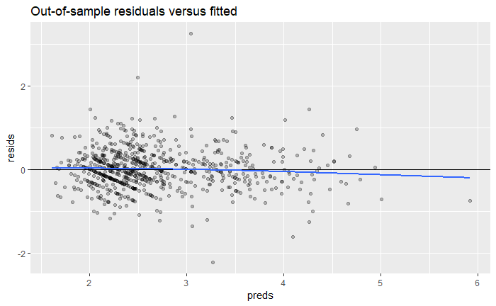

```r
data.frame(
  actual = holdoutdat %>% filter(rv.gave == TRUE) %>% select(rv.amt) %>% unlist()
  , preds = predict(lm_trained_fewsplines, newdata = holdoutdat %>% filter(rv.gave == TRUE))
) %>% mutate(
  resids = actual - preds
) %>%
  ggplot(aes(x = preds, y = resids)) +
  geom_hline(yintercept = 0) +
  geom_point(alpha = .25) +
  geom_smooth(se = FALSE, method = 'gam', formula = y ~ s(x, bs = 'cs')) +
  labs(title = 'Out-of-sample residuals versus fitted')
```

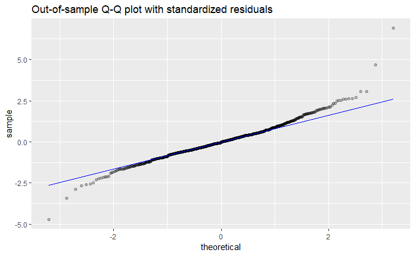

```r
data.frame(
  actual = holdoutdat %>% filter(rv.gave == TRUE) %>% select(rv.amt) %>% unlist()
  , preds = predict(lm_trained_fewsplines, newdata = holdoutdat %>% filter(rv.gave == TRUE))
) %>% mutate(
  resids = actual - preds
  , st.resid = resids/sd(resids)
) %>%
  ggplot(aes(sample = st.resid)) +
  geom_qq(alpha = .25) +
  geom_qq_line(color = 'blue') +
  labs(title = 'Out-of-sample Q-Q plot with standardized residuals'
       , color = 'cross-validation sample')
```

The out-of-sample diagnostic plots are in line with my previous results.

# Combined model

Use the GAM probability model and small linear regression model.

```r
gam_final <- gam(
  rv.gave ~
  PROGRAM_GROUP +
  PREF_ADDR_TYPE_CODE +
  HOUSEHOLD_CONTINENT +
  BUS_IS_EMPLOYED +
  HAS_HOME_ADDR +
  HAS_HOME_PHONE +
  s(YEARS_SINCE_FIRST_GIFT, k = giving) +
  s(GIVING_FIRST_YEAR_CASH_AMT, k = giving) +
  s(GIVING_MAX_PLEDGE_AMT, k = giving) +
  s(GIVING_CASH_TOTAL, k = giving) +
  s(GIVING_PLEDGE_TOTAL, k = giving) +
  s(GIVING_CRU_TOTAL, k = giving) +
  s(GIFTS_ALLOCS_SUPPORTED, k = giving) +
  s(GIFTS_FYS_SUPPORTED, k = giving) +
  s(GIFTS_CASH, k = giving) +
  s(GIFTS_PLEDGES, k = giving) +
  s(CASH_PFY1, k = dollars) +
  s(CASH_PFY2, k = dollars) +
  s(CASH_PFY3, k = dollars) +
  s(CASH_PFY4, k = dollars) +
  s(CASH_PFY5, k = dollars) +
  CRU_GIVING_SEGMENT +
  s(EVALUATION_LOWER_BOUND, k = dollars) +
  s(UOR_LOWER_BOUND, k = dollars) +
  s(MONTHS_ASSIGNED, k = engagement) +
  s(COMMITTEE_NU_DISTINCT, k = engagement) +
  s(COMMITTEE_NU_YEARS, k = engagement) +
  s(COMMITTEE_KSM_DISTINCT, k = engagement) +
  s(EVENTS_PREV_3_FY, k = engagement) +
  s(EVENTS_CFY, k = engagement) +
  s(EVENTS_PFY1, k = engagement) +
  s(ATHLETICS_TICKET_YEARS, k = engagement) +
  s(YEARS_SINCE_ATHLETICS_TICKETS, k = engagement) +
  s(RECORD_YR, k = recordyr) +
  s(YEARS_SINCE_MAX_CASH_YR, k = giving) +
  GIVING_MAX_CASH_MO +
  KSM_PROSPECT +
  s(VISITORS_5FY, k = engagement) +
  LOYAL_5_PCT_CASH +
  UPGRADE3_CASH +
  VELOCITY3_LIN_CASH +
  SPOUSE_ALUM
  , data = modeling.data
  , family = 'binomial'
  , control = list(nthreads = 10)
)
```

```
basis dimension, k, increased to minimum possible
basis dimension, k, increased to minimum possible
basis dimension, k, increased to minimum possible
basis dimension, k, increased to minimum possible
basis dimension, k, increased to minimum possible
basis dimension, k, increased to minimum possible
basis dimension, k, increased to minimum possible
basis dimension, k, increased to minimum possible
basis dimension, k, increased to minimum possible
basis dimension, k, increased to minimum possible
```

```r
# Save output
save(gam_final, file = 'data/06_gam_final.Rdata')
```

```r
lm_final <- lm(
  rv.amt ~
  COMMITTEE_KSM_LDR +
  ns(CRU_PFY1, df = 2) +
  ns(CRU_PFY2, df = 1) +
  ns(CRU_PFY3, df = 1) +
  ns(CRU_PFY4, df = 1) +
  ns(CRU_PFY5, df = 1) +
  ns(EVALUATION_LOWER_BOUND, df = 1) +
  GIFT_CLUB_NU_LDR_YRS +
  ns(GIFTS_ALLOCS_SUPPORTED, df = 1) +
  ns(GIFTS_OUTRIGHTS_PAYMENTS, df = 1) +
  ns(GIVING_CRU_TOTAL, df = 1) +
  ns(GIVING_MAX_CASH_YR, df = 1) +
  ns(GIVING_MAX_PLEDGE_AMT, df = 1) +
  ns(GIVING_MAX_PLEDGE_FY, df = 1) +
  HOUSEHOLD_CONTINENT +
  KSM_GOS_FLAG +
  LOYAL_5_PCT_ANY +
  ns(NGC_PFY1, df = 2) +
  ns(NGC_PFY2, df = 1) +
  ns(NGC_PFY3, df = 1) +
  ns(NGC_PFY4, df = 1) +
  ns(NGC_PFY5, df = 1) +
  PREF_ADDR_TYPE_CODE +
  PROGRAM_GROUP +
  ns(RECORD_YR, df = 5) +
  ns(UOR_LOWER_BOUND, df = 1) +
  UPGRADE3_CASH +
  ns(VELOCITY3_LIN_NGC, df = 7) +
  ns(VISITS_5FY, df = 1)
  , data = modeling.data %>% filter(rv.gave == TRUE)
)
```

```r
save(lm_final, file = 'data/06_lm_final.Rdata')
```

```r
error_compare <- data.frame(
  giving = log10plus1(modeling.data$rv.amt, inverse = TRUE)
  , log.giving = modeling.data$rv.amt
  , gave = modeling.data$rv.gave
  , est.giving = predict(lm_final, newdata = modeling.data, type = 'response')
  , est.gave = gam_final$fitted
) %>% mutate(
  ev = est.giving * est.gave
  , error = log.giving - ev
  , log.giving.bin = trunc(log.giving)
  , pred.giving.bin = trunc(est.giving)
  , ev.bin = trunc(ev)
)
```

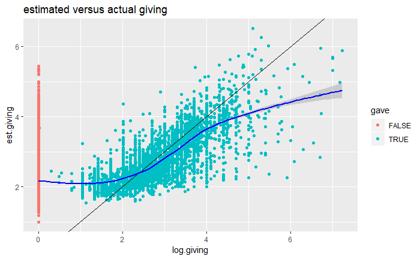

```r
error_compare %>%
  ggplot(aes(x = log.giving, y = est.giving, color = gave)) +
  geom_point() +
  geom_abline(aes(slope = 1, intercept = 0)) +
  geom_smooth(method = 'gam', formula = y ~ s(x, bs = 'cs'), color = 'blue') +
  labs(title = 'estimated versus actual giving')
```

```r
paste('mse =', calc_mse(y = error_compare$log.giving, yhat = error_compare$est.giving))
```

```
[1] "mse = 4.40203640955111"
```

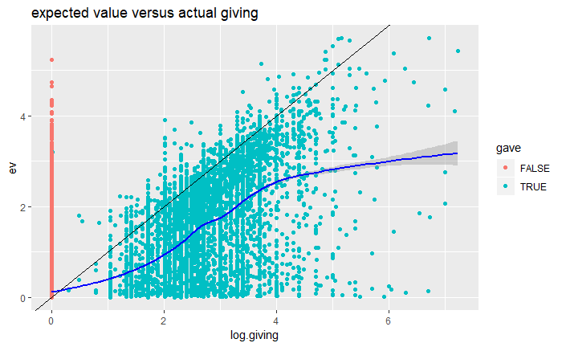

```r
error_compare %>%
  ggplot(aes(x = log.giving, y = ev, color = gave)) +
  geom_point() +
  geom_abline(aes(slope = 1, intercept = 0)) +
  geom_smooth(method = 'gam', formula = y ~ s(x, bs = 'cs'), color = 'blue') +
  labs(title = 'expected value versus actual giving')
```

```r
paste('mse =', calc_mse(y = error_compare$log.giving, yhat = error_compare$ev))
```

```
[1] "mse = 0.303359675401254"
```

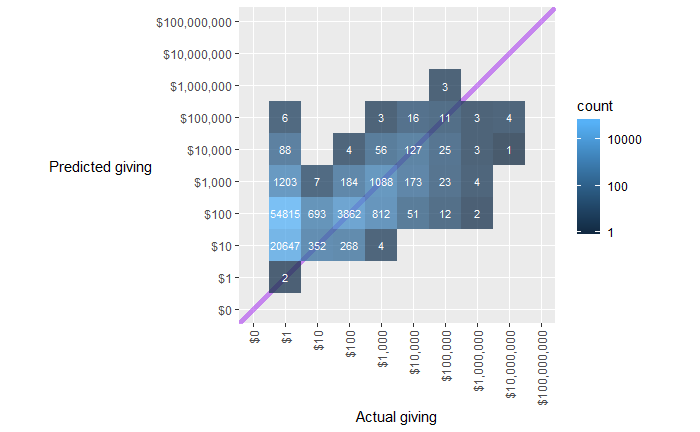

```r
error_bin <- error_compare %>%
  group_by(log.giving.bin, pred.giving.bin) %>%
  summarise(n = length(gave), g = sum(gave))
mingift <- -1
maxgift <- 8
error_bin %>%
  ggplot(aes(x = log.giving.bin, y = pred.giving.bin, fill = n)) +
  geom_abline(color = 'purple', size = 2, alpha = .5) +
  geom_tile(alpha = .75) +
  geom_text(aes(label = n), color = 'white', size = 3) +
  scale_fill_gradient(name = 'count', trans = 'log10') +
  scale_x_continuous(breaks = mingift:maxgift, minor_breaks = NULL
                     , labels = 10^(mingift:maxgift) %>% scales::dollar(), limits = c(mingift, maxgift)) +
  scale_y_continuous(breaks = mingift:maxgift, minor_breaks = NULL
                     , labels = 10^(mingift:maxgift) %>% scales::dollar(), limits = c(mingift, maxgift)) +
  coord_equal() +
  theme(axis.text.x = element_text(angle = 90, hjust = 1, vjust = .5), axis.title.y = element_text(angle = 0, vjust = .5)) +
  labs(x = 'Actual giving', y = 'Predicted giving')
```

- Total giving during the out-of-sample time period was $128,881,529.
- Those predicted to give at least $1,000 gave $116,205,842, or 90.2% of the total.
- A total of 3032 donors were predicted to give at the $1,000 level and 1540 actually did, for a hit rate of 50.8%.
- Average giving in this group is $38,326.47 per person.
- This method elimintates 81520 entities, who gave a total of $12,675,687, or an average of $155.49 per person.

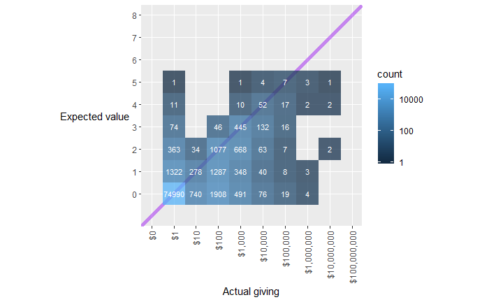

```r
ev_bin <- error_compare %>%
  group_by(log.giving.bin, ev.bin) %>%
  summarise(n = length(gave), g = sum(gave))
mingift <- -1
maxgift <- 8
ev_bin %>%
  ggplot(aes(x = log.giving.bin, y = ev.bin, fill = n)) +
  geom_abline(color = 'purple', size = 2, alpha = .5) +
  geom_tile(alpha = .75) +
  geom_text(aes(label = n), color = 'white', size = 3) +
  scale_fill_gradient(name = 'count', trans = 'log10') +
  scale_x_continuous(breaks = mingift:maxgift, minor_breaks = NULL
                     , labels = 10^(mingift:maxgift) %>% scales::dollar(), limits = c(mingift, maxgift)) +
  scale_y_continuous(breaks = 0:maxgift, minor_breaks = NULL, limits = c(mingift, maxgift)) +
  coord_equal() +
  theme(axis.text.x = element_text(angle = 90, hjust = 1, vjust = .5), axis.title.y = element_text(angle = 0, vjust = .5)) +
  labs(x = 'Actual giving', y = 'Expected value')
```

- Total giving during the out-of-sample time period was again $128,881,529.
- Entities with a score of 1 or higher (6324 total) gave $112,439,016, or 87.2% of the total.
- Of these 6324 entities, 4557 were donors (72.1%), and 1831 gave at least $1,000 (29.0%).
- Average giving in this group is $17,779.73 per person.
- This method elimintates 78228 entities, who gave a total of $16,442,513, or an average of $210.19 per person.

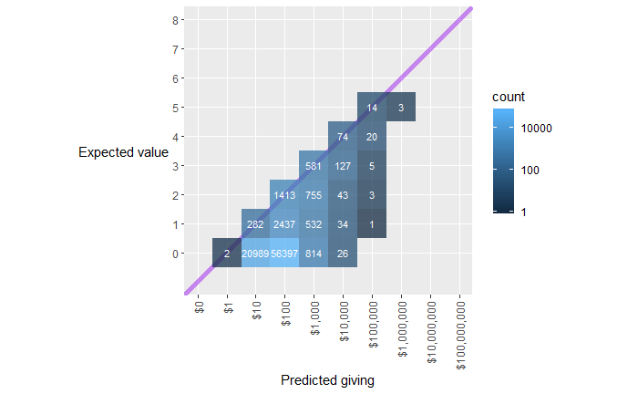

```r
both_bin <- error_compare %>%
  group_by(pred.giving.bin, ev.bin) %>%
  summarise(n = length(gave), g = sum(gave))
mingift <- -1
maxgift <- 8
both_bin %>%
  ggplot(aes(x = pred.giving.bin, y = ev.bin, fill = n)) +
  geom_abline(color = 'purple', size = 2, alpha = .5) +
  geom_tile(alpha = .75) +
  geom_text(aes(label = n), color = 'white', size = 3) +
  scale_fill_gradient(name = 'count', trans = 'log10') +
  scale_x_continuous(breaks = mingift:maxgift, minor_breaks = NULL
                     , labels = 10^(mingift:maxgift) %>% scales::dollar(), limits = c(mingift, maxgift)) +
  scale_y_continuous(breaks = 0:maxgift, minor_breaks = NULL, limits = c(mingift, maxgift)) +
  coord_equal() +
  theme(axis.text.x = element_text(angle = 90, hjust = 1, vjust = .5), axis.title.y = element_text(angle = 0, vjust = .5)) +
  labs(x = 'Predicted giving', y = 'Expected value')
```

- Of the 840 individuals with a relatively high predicted giving amount ($1,000) but a 0 expected value score, only 134 were actually donors (16.0%), giving a total of $6,482,368.

This is in line with (better than!) my [previous results](https://phively.github.io/ksm-models/pg-cultivation-score-fy18/05%20KSM%20predictive%20model.nb.html#conclusions) on untuned models.